# BTS 510 Lab 12

```r
set.seed(12345)
library(tidyverse)
library(Stat2Data)
theme_set(theme_classic(base_size = 16))
```

## 1 Learning objectives

- **Conduct** Poisson regression for *count outcomes*
- **Interpret** results in terms of *predicted counts*
- **Describe** when to use alternative models / specifications
  - Negative binomial, inflated zeroes, offset, etc.

## 2 Data

- Read in data from text file: `jpapoisson.txt`

```r
dat <- read_table("jpapoisson.txt",
                  col_names = FALSE)
colnames(dat) <- c("ID", "sensation", "sex", "alcohol")
head(dat)
```

```
# A tibble: 6 × 4
     ID sensation   sex alcohol
  <dbl>     <dbl> <dbl>   <dbl>
1     1      6.06     1       4
2     2      5.31     1       4
3     3      3.94     1       1
4     4      4.30     1       6
5     5      5.58     1       0
6     6      4.89     1       8
```

- $n$ = **400** observations on 4 variables
  - `ID`: ID variable
  - `sensation`: 1 to 7 scale of sensation seeking
  - `sex`: 0 = female, 1 = male
  - `alcohol`: count of number of alcoholic drinks consumed

## 3 Analysis

- Extend the analysis from the lecture
  - `sensation` and `sex` predict `alcohol`
  - Be sure to mean center `sensation` for interpretability

```r
dat <- dat %>%
  mutate(sensationC = sensation - mean(sensation, na.rm = TRUE))
```

## 4 Tasks

- Model 1: Poisson regression for `alcohol ~ sensation + sex`
- Model 2: Negative binomial for `alcohol ~ sensation + sex`

```r
m1 <- glm(data = dat,
          alcohol ~ sensationC + sex,
          family = poisson(link = "log"))
```

```r
library(MASS)
m2 <- glm.nb(data = dat,
             alcohol ~ sensationC + sex)
```

1. How can we compare models 1 and 2? Do that comparison. Which model is preferred?
- Complicated nesting situations #1
  - Use Vuong test or AIC

```r
library(pscl)
vuong(m1, m2)
```

```
Vuong Non-Nested Hypothesis Test-Statistic:
(test-statistic is asymptotically distributed N(0,1) under the
 null that the models are indistinguishible)
-------------------------------------------------------------
              Vuong z-statistic             H_A   p-value
Raw                   -5.730019 model2 > model1 5.021e-09
AIC-corrected         -5.730019 model2 > model1 5.021e-09
BIC-corrected         -5.730019 model2 > model1 5.021e-09
```

```r
AIC(m1)
```

```
[1] 1888.795
```

```r
AIC(m2)
```

```
[1] 1707.023
```

2. Report the full results of the preferred model.
- Report the $R^2$ for the model
- For each coefficient (including intercept), report:
  - Regression coefficient
  - Standard error
  - $z$ statistic
  - $p$ value

```r
summary(m2)
```

```
Call:
glm.nb(formula = alcohol ~ sensationC + sex, data = dat, init.theta = 1.958997319,
    link = log)

Coefficients:
            Estimate Std. Error z value Pr(>|z|)
(Intercept)  0.57514    0.07264   7.918 2.42e-15 ***
sensationC   0.23510    0.06216   3.782 0.000156 ***
sex          0.82236    0.09580   8.584  < 2e-16 ***
---
Signif. codes:  0 '***' 0.001 '**' 0.01 '*' 0.05 '.' 0.1 ' ' 1

(Dispersion parameter for Negative Binomial(1.959) family taken to be 1)

    Null deviance: 548.45  on 399  degrees of freedom
Residual deviance: 459.77  on 397  degrees of freedom
AIC: 1707

Number of Fisher Scoring iterations: 1

              Theta:  1.959
          Std. Err.:  0.268

 2 x log-likelihood:  -1699.023
```

```r
summary(m1)
```

```
Call:
glm(formula = alcohol ~ sensationC + sex, family = poisson(link = "log"),
    data = dat)

Coefficients:
            Estimate Std. Error z value Pr(>|z|)
(Intercept)  0.56334    0.05248  10.734  < 2e-16 ***
sensationC   0.26085    0.03882   6.719 1.83e-11 ***
sex          0.83947    0.06292  13.342  < 2e-16 ***
---
Signif. codes:  0 '***' 0.001 '**' 0.01 '*' 0.05 '.' 0.1 ' ' 1

(Dispersion parameter for poisson family taken to be 1)

    Null deviance: 1186.76  on 399  degrees of freedom
Residual deviance:  959.46  on 397  degrees of freedom
AIC: 1888.8

Number of Fisher Scoring iterations: 5
```

- $R^2_{deviance} = 1 - \frac{deviance_{model}}{deviance_{null}} = 1 - \frac{459.77}{548.45} = 0.162$
  - A negative binomial model with predictors sensation seeking and sex accounts for 16.2% of the variance in number of alcoholic beverages consumed
- Intercept: $b_0 = 0.575, s.e. = 0.073, z = 7.918, p<.0001$
  - The natural log of the predicted count for **women** with **mean sensation seeking**
  - Predicted count = $e^{0.575} = 1.777$
- Sensation seeking: $b_1 = 0.235, s.e. = 0.062, z = 3.782, p<.001$
  - Rate ratio = $e^{0.235} = 1.265$
  - For each one unit increase in sensation seeking, the expected count is **multiplied by** 1.265, holding sex constant
- Sex: $b_2 = 0.822, s.e. = 0.096, z = 8.584, p<.0001$
  - Rate ratio = $e^{0.822} = 2.276$
  - For each one unit increase in sex (i.e., going from female to male), the expected count is **multiplied by** 2.276, holding sensation seeking constant
  - Men drink 2.276 times as many drinks as women, on average, holding sensation seeking constant
3. Calculate predicted counts for `alcohol` for 6 predictor combinations:
- Male, low sensation seeking
- Male, mean sensation seeking
- Male, high sensation seeking
- Female, low sensation seeking
- Female, mean sensation seeking
- Female, high sensation seeking

```r
sqrt(var(dat$sensationC))
```

```
[1] 0.7682503
```

```r
sensationC <- c(-0.7682503, 0, 0.7682503)
sex <- c(0, 0, 0, 1, 1, 1)
vals <- data.frame(sensationC, sex)
predict(m2, newdata = vals, type = "response")
```

```
       1        2        3        4        5        6
1.483677 1.777375 2.129212 3.376640 4.045056 4.845787
```

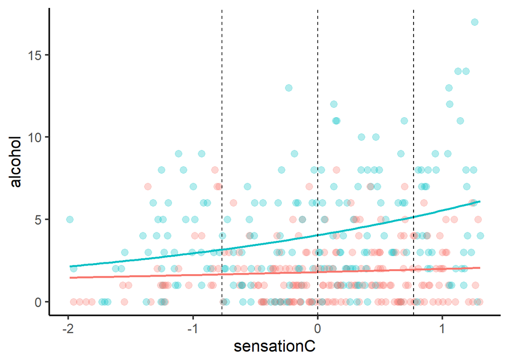

```r
ggplot(data = dat,
       aes(x = sensationC,
           y = alcohol,
           group = factor(sex),
           color = factor(sex))) +
  geom_point(size = 3, alpha = 0.3) +
  stat_smooth(method="glm",
              method.args=list(family="poisson"),
              se=FALSE,
              fullrange = T) +
  theme(legend.position="none") +
  geom_vline(xintercept = -0.7682503, linetype = "dashed") +
  geom_vline(xintercept = 0, linetype = "dashed") +
  geom_vline(xintercept = 0.7682503, linetype = "dashed")
```

4. Report the **rate ratios** for each predictor and their confidence intervals. Interpret the **rate ratios** in words.

```r
exp(coef(m2))
```

```
(Intercept)  sensationC         sex
   1.777375    1.265033    2.275859
```

```r
exp(confint(m2))
```

```
               2.5 %   97.5 %
(Intercept) 1.541306 2.048929
sensationC  1.121357 1.427775
sex         1.887818 2.746260
```

## 5 Bonus task: Are there excess zeroes?

- Zero-inflated Poisson
  - `y ~ count_predictors | logistic_predictors`

```r
library(pscl)
zip <- zeroinfl(alcohol ~ sensationC + sex | sensationC + sex,
                data = dat,
                dist = "poisson")
summary(zip)
```

```
Call:
zeroinfl(formula = alcohol ~ sensationC + sex | sensationC + sex, data = dat,
    dist = "poisson")

Pearson residuals:
    Min      1Q  Median      3Q     Max
-1.8577 -1.0053 -0.3412  0.7368  4.5238

Count model coefficients (poisson with log link):
            Estimate Std. Error z value Pr(>|z|)
(Intercept)  0.82435    0.06023  13.688  < 2e-16 ***
sensationC   0.21637    0.04191   5.162 2.44e-07 ***
sex          0.70714    0.07006  10.094  < 2e-16 ***

Zero-inflation model coefficients (binomial with logit link):
            Estimate Std. Error z value Pr(>|z|)
(Intercept)  -1.2460     0.2164  -5.757 8.56e-09 ***
sensationC   -0.2021     0.2115  -0.956   0.3392
sex          -0.7202     0.3159  -2.280   0.0226 *
---
Signif. codes:  0 '***' 0.001 '**' 0.01 '*' 0.05 '.' 0.1 ' ' 1

Number of iterations in BFGS optimization: 12
Log-likelihood: -887.4 on 6 Df
```

- Zero-inflated negative binomial
  - `y ~ count_predictors | logistic_predictors`

```r
library(pscl)
zinb <- zeroinfl(alcohol ~ sensationC + sex | sensationC + sex,
                 data = dat,
                 dist = "negbin")
summary(zinb)
```

```
Call:
zeroinfl(formula = alcohol ~ sensationC + sex | sensationC + sex, data = dat,
    dist = "negbin")

Pearson residuals:
    Min      1Q  Median      3Q     Max
-1.2911 -0.8209 -0.2766  0.6005  4.0667

Count model coefficients (negbin with log link):
            Estimate Std. Error z value Pr(>|z|)
(Intercept)  0.68220    0.09344   7.301 2.85e-13 ***
sensationC   0.21540    0.06944   3.102  0.00192 **
sex          0.78326    0.10973   7.138 9.47e-13 ***
Log(theta)   1.04795    0.22765   4.603 4.16e-06 ***

Zero-inflation model coefficients (binomial with logit link):
            Estimate Std. Error z value Pr(>|z|)
(Intercept)  -2.1844     0.6871  -3.179  0.00148 **
sensationC   -0.2689     0.5642  -0.477  0.63363
sex          -0.5000     0.7623  -0.656  0.51185
---
Signif. codes:  0 '***' 0.001 '**' 0.01 '*' 0.05 '.' 0.1 ' ' 1

Theta = 2.8518
Number of iterations in BFGS optimization: 24
Log-likelihood: -847.3 on 7 Df
```

- Hurdle Poisson
  - `y ~ count_predictors | logistic_predictors`

```r
library(pscl)
hurdle_poi <- hurdle(alcohol ~ sensationC + sex | sensationC + sex,
                     data = dat,
                     dist = "poisson")
summary(hurdle_poi)
```

```
Call:
hurdle(formula = alcohol ~ sensationC + sex | sensationC + sex, data = dat,
    dist = "poisson")

Pearson residuals:
    Min      1Q  Median      3Q     Max
-1.8758 -1.0123 -0.3459  0.7397  4.5353

Count model coefficients (truncated poisson with log link):
            Estimate Std. Error z value Pr(>|z|)
(Intercept)  0.81974    0.06058  13.531  < 2e-16 ***
sensationC   0.22099    0.04170   5.299 1.16e-07 ***
sex          0.71233    0.07012  10.158  < 2e-16 ***
Zero hurdle model coefficients (binomial with logit link):
            Estimate Std. Error z value Pr(>|z|)
(Intercept)   0.8435     0.1536   5.490 4.01e-08 ***
sensationC    0.2866     0.1624   1.765   0.0776 .
sex           1.0276     0.2606   3.944 8.02e-05 ***
---
Signif. codes:  0 '***' 0.001 '**' 0.01 '*' 0.05 '.' 0.1 ' ' 1

Number of iterations in BFGS optimization: 9
Log-likelihood: -887.1 on 6 Df
```

- Hurdle negative binomial
  - `y ~ count_predictors | logistic_predictors`

```r
library(pscl)
hurdle_nb <- hurdle(alcohol ~ sensationC + sex | sensationC + sex,
                    data = dat,
                    dist = "negbin")
summary(hurdle_nb)
```

```
Call:
hurdle(formula = alcohol ~ sensationC + sex | sensationC + sex, data = dat,
    dist = "negbin")

Pearson residuals:
    Min      1Q  Median      3Q     Max
-1.2795 -0.8352 -0.2848  0.6023  4.0849

Count model coefficients (truncated negbin with log link):
            Estimate Std. Error z value Pr(>|z|)
(Intercept)  0.68406    0.08897   7.689 1.49e-14 ***
sensationC   0.22623    0.06430   3.519 0.000434 ***
sex          0.78248    0.10345   7.564 3.91e-14 ***
Log(theta)   1.06127    0.22604   4.695 2.67e-06 ***
Zero hurdle model coefficients (binomial with logit link):
            Estimate Std. Error z value Pr(>|z|)
(Intercept)   0.8435     0.1536   5.490 4.01e-08 ***
sensationC    0.2866     0.1624   1.765   0.0776 .
sex           1.0276     0.2606   3.944 8.02e-05 ***
---
Signif. codes:  0 '***' 0.001 '**' 0.01 '*' 0.05 '.' 0.1 ' ' 1

Theta: count = 2.89
Number of iterations in BFGS optimization: 11
Log-likelihood: -847.4 on 7 Df
```

### 5.1 Comparisons

- No overdispersion, does modeling inflated zeroes help?
  - Yes
  - So can we model **either** overdispersion or inflated zeroes? Do we need both?

```r
vuong(m1, zip)
```

```
Vuong Non-Nested Hypothesis Test-Statistic:
(test-statistic is asymptotically distributed N(0,1) under the
 null that the models are indistinguishible)
-------------------------------------------------------------
              Vuong z-statistic             H_A    p-value
Raw                   -4.123098 model2 > model1 1.8691e-05
AIC-corrected         -3.893880 model2 > model1 4.9327e-05
BIC-corrected         -3.436422 model2 > model1 0.00029473
```

```r
vuong(m1, hurdle_poi)
```

```
Vuong Non-Nested Hypothesis Test-Statistic:
(test-statistic is asymptotically distributed N(0,1) under the
 null that the models are indistinguishible)
-------------------------------------------------------------
              Vuong z-statistic             H_A    p-value
Raw                   -4.144692 model2 > model1 1.7014e-05
AIC-corrected         -3.915727 model2 > model1 4.5066e-05
BIC-corrected         -3.458774 model2 > model1 0.00027132
```

```r
vuong(m2, zinb)
```

```
Vuong Non-Nested Hypothesis Test-Statistic:
(test-statistic is asymptotically distributed N(0,1) under the
 null that the models are indistinguishible)
-------------------------------------------------------------
              Vuong z-statistic             H_A    p-value
Raw                  -1.0879030 model2 > model1 0.13831897
AIC-corrected         0.4203742 model1 > model2 0.33710607
BIC-corrected         3.4304915 model1 > model2 0.00030124
```

```r
vuong(m2, hurdle_nb)
```

```
Vuong Non-Nested Hypothesis Test-Statistic:
(test-statistic is asymptotically distributed N(0,1) under the
 null that the models are indistinguishible)
-------------------------------------------------------------
              Vuong z-statistic             H_A    p-value
Raw                  -1.0534565 model2 > model1 0.14606592
AIC-corrected         0.4087546 model1 > model2 0.34135989
BIC-corrected         3.3269364 model1 > model2 0.00043903
```

- Have inflated zeroes, does modeling overdispersion help?
  - Yes, if we already have inflated zeroes, overdispersion too makes a better model

```r
vuong(zip, zinb)
```

```
Vuong Non-Nested Hypothesis Test-Statistic:
(test-statistic is asymptotically distributed N(0,1) under the
 null that the models are indistinguishible)
-------------------------------------------------------------
              Vuong z-statistic             H_A    p-value
Raw                   -4.070597 model2 > model1 2.3446e-05
AIC-corrected         -4.070597 model2 > model1 2.3446e-05
BIC-corrected         -4.070597 model2 > model1 2.3446e-05
```

```r
vuong(hurdle_poi, hurdle_nb)
```

```
Vuong Non-Nested Hypothesis Test-Statistic:
(test-statistic is asymptotically distributed N(0,1) under the
 null that the models are indistinguishible)
-------------------------------------------------------------
              Vuong z-statistic             H_A    p-value
Raw                   -4.066874 model2 > model1 2.3824e-05
AIC-corrected         -4.066874 model2 > model1 2.3824e-05
BIC-corrected         -4.066874 model2 > model1 2.3824e-05
```